# Basic R for all

# การใช้ R ขั้นพื้นฐานสำหรับการวิเคราะห์ทางสถิติ

ในการวิเคราะห์สถิติขั้นพื้นฐาน มีขั้นตอนที่สำคัญที่เราจะค่อย ๆ ทำไปที่ละขั้น

หากเราทำความรู้จัก Code พื้นฐานสำคัญของ R จะทำให้เราเข้าใจภาษา R ง่ายยิ่งขึ้น

ใน Demo นี้ เราจะทำความรู้จักสมการหรือภาษาของ R และ คำสั่ง (function) พื้นฐานกัน

## พื้นฐานสุด ๆ

สมมติว่าเราต้องการให้ R ทำงานเปรียบเสมือนเครื่องคิดเลข เราสามารถสั่งคำสั่งได้โดยการใช้ เครื่องหมาย `+, -, *, /` (บวก ลบ คูณ และหาร ตามลำดับ)

```r
3 + 6
```

```
## [1] 9
```

```r
3 - 6
```

```
## [1] -3
```

```r
3 * 6
```

```
## [1] 18
```

```r
3 / 6
```

```
## [1] 0.5
```

ผลที่ R แสดงขึ้นมาคือผลที่เราต้องการหาคำตอบค่า

## รู้จักชนิดของวัตถุใน R

วัตถุ หรือ `object` ใน R มีหลายประเภท โดยพื้นฐานแล้ว เราจะใช้ `vector` `array` `matrix` `dataframe` โดยแต่ละชนิดอาจะมีวิธีการเรียกใช้แตกต่างกันไปบ้าง

```r
vector1 <- c(1, 2, 3, 4, 5, 6)

vector2 <- c(0, 1, 2, 3, 4, 5)

vector3 <- c("a", "b", "c", "d", "e")

vector4 <- c(1.3, 1.2, 1.4, 1.5, 1.1)

array <- rbind(vector1, vector2, vector3)

matrix <- matrix(1:6, 6, 6)
matrix
```

```
##      [,1] [,2] [,3] [,4] [,5] [,6]
## [1,]    1    1    1    1    1    1
## [2,]    2    2    2    2    2    2
## [3,]    3    3    3    3    3    3
## [4,]    4    4    4    4    4    4
## [5,]    5    5    5    5    5    5
## [6,]    6    6    6    6    6    6
```

```r
dataframe <- data.frame(matrix)
dataframe
```

```
##   X1 X2 X3 X4 X5 X6
## 1  1  1  1  1  1  1
## 2  2  2  2  2  2  2
## 3  3  3  3  3  3  3
## 4  4  4  4  4  4  4
## 5  5  5  5  5  5  5
## 6  6  6  6  6  6  6
```

จะเห็นได้ว่า `vector` คือเลขเรียงลำดับในบรรทักเดียวไปเรื่อย ๆ ในขณะที่ `Array` จะเป็น `vector` ที่มีหลายมิติ `Matrix` คือเลขที่มีทั้งแถว (row) และสดมภ์ (column๗ เช่นเดียวกับ `dataframe` แต่ `dataframe` จะบ่งบอกลักษณะได้หลายประการมากกว่า โดยจะมี `structure` คือ ชื่อตัวแปร ลักษณะของตัวแปร และจำนวนของ `observation` (แถว) นี่เอง

ที่นี้เราลองมาใช้การคำนวณใน object ที่เราสร้างมากัน

```r
vector1 + vector2
```

```
## [1]  1  3  5  7  9 11
```

```r
vector1 * vector2
```

```
## [1]  0  2  6 12 20 30
```

สังเกตว่า vector1 กับ vector2 เมื่อ บวก และ คูณ กันจะได้ผลลัพธ์ตาม output ด้านบนนี้

ลักษณะการคำนวณเช่นนี้ `dataframe` จะไม่แตกต่างจาก `matrix` เท่าไหร่นัก เดี๋ยวเราไปรู้จักชนิดของข้อมูลการดีกว่า

## ชนิดของข้อมูลที่เราคีย์ใน R

ข้อมูลที่เราได้จาก database หรือการเก็บมาเองจะมีลำดับของมาตรส่วน หรือที่เรียกว่า Level of Measurements

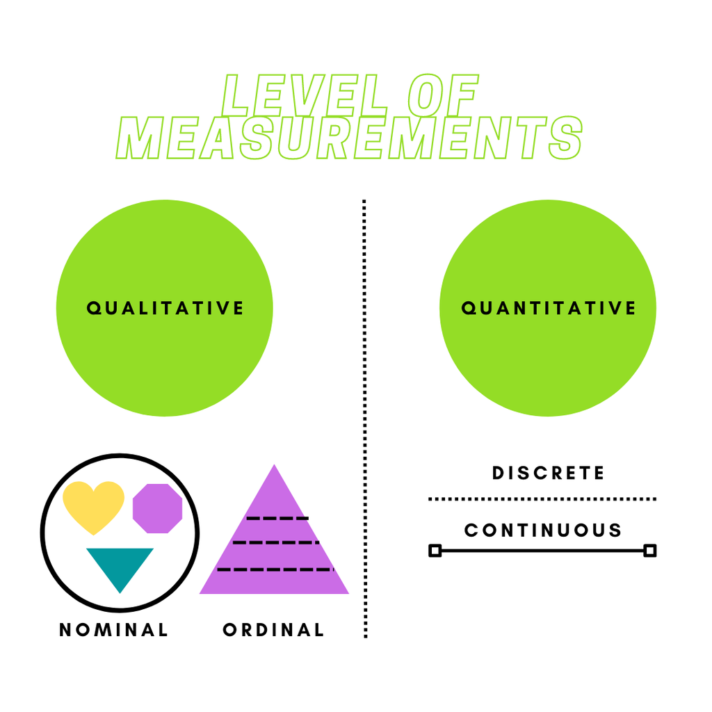

ใน R เราจะรู้จัก `level` เหล่านี้ได้ในอีกรูปแบบต่างออกไปคือ `Qualitative = Factor` ซึ่งส่วนใหญ่นักวิจัยหรือนักวิเคราะห์จะ `key` ข้อมูลเหล่านี้เป็นตัวอักษร หรือ `charactor` และ `Quantitative = Numeric` ซึ่งเป็นเป็นตัวเลขที่มีทศนิยมหรือไม่มีก็ได้

```r
typeof(vector1)
```

```
## [1] "double"
```

```r
typeof(vector3)
```

```
## [1] "character"
```

```r
typeof(vector4)
```

```
## [1] "double"
```

```r
class(vector1)
```

```
## [1] "numeric"
```

```r
class(vector3)
```

```
## [1] "character"
```

```r
class(vector4)
```

```
## [1] "numeric"
```

เพราะฉะนั้น การ key ข้อมูลใน R จะมี 2 ลักษณะคือ เมื่อไหร่ก็ตามที่เราคีย์เป็นตัวเลข R จะจัดให้เป็น numeric และถ้าเราคีย์เป็นตัวอักษร R โดยการใส่เครื่องหมายคำพูด (quotation) `"____"` จะจัดให้เป็น character หากต้องการเปลี่ยนลักษณะของข้อมูล สามารถทำได้หลาย (มากๆ) วิธีด้วยกัน เราชอบใช้ `as.________` ที่สุด (ง่ายดี)

## การเปลี่ยนชนิดข้อมูลใน R

`Demo` นี้เราจะใช้ `dataset` ชื่อว่า coronavirus ที่มาจาก Package ชื่อว่า coronavirus

เนื่องจากว่า R มีนักพัฒนาใจดีทั่วโลกร่วมกันเขียน package ออกมาหลากหลาย (ดูได้ใน Cran.R) การเรียก package ออกมาเราจะต้องทำการติดตั้ง package นั้นเสียก่อน โดยใช้ คำสั่ง `install.packages("_____")` ต้องมีเครื่องหมาย Quatation ด้วยนะ และเรียก package นั้นออกมาด้วยคำสั่ง `library()`

เนื่องจากว่า เรามีตัวแปรที่เป็น**กลุ่ม** (เช่น เพศ ลำดับในองค์กร พื้นที่) และ**ข้อมูลต่อเนื่อง** (เช่น มาตรวัด น้ำหนัก อายุ ส่วนสูง) เราจึงต้องจัดชนิดของข้อมูลใน R ให้เหมาะสมด้วยการเขียนคำสั่ง เช่น

```r
#install.packages("coronavirus")
library(coronavirus)
head(coronavirus)
```

```
##         date province country     lat      long      type cases   uid iso2 iso3
## 1 2020-01-22  Alberta  Canada 53.9333 -116.5765 confirmed     0 12401   CA  CAN
## 2 2020-01-23  Alberta  Canada 53.9333 -116.5765 confirmed     0 12401   CA  CAN
## 3 2020-01-24  Alberta  Canada 53.9333 -116.5765 confirmed     0 12401   CA  CAN
## 4 2020-01-25  Alberta  Canada 53.9333 -116.5765 confirmed     0 12401   CA  CAN
## 5 2020-01-26  Alberta  Canada 53.9333 -116.5765 confirmed     0 12401   CA  CAN
## 6 2020-01-27  Alberta  Canada 53.9333 -116.5765 confirmed     0 12401   CA  CAN
##   code3    combined_key population continent_name continent_code
## 1   124 Alberta, Canada    4413146  North America             NA
## 2   124 Alberta, Canada    4413146  North America             NA
## 3   124 Alberta, Canada    4413146  North America             NA
## 4   124 Alberta, Canada    4413146  North America             NA
## 5   124 Alberta, Canada    4413146  North America             NA
## 6   124 Alberta, Canada    4413146  North America             NA
```

```r
typeof(coronavirus)
```

```
## [1] "list"
```

```r
class(coronavirus)
```

```
## [1] "data.frame"
```

`dataset` นี้มีลักษณะเป็น `list` โดยมีข้อมูลเป็น `data.frame` ใน `dataset` นี้ มีตัวแปรแบบกลุ่มที่เห็นได้ชัดคือ `country` และ `province` ในขณะที่ตัวแปรแบบต่อเนื่องคือ จำนวน `case` `population` (ที่เหลือเดี๋ยวสนุกแล้วกลับมาเล่นได้นะ)

เราจะเรียกใช้เพียง country province case population เท่านั้น วิธีการด้านล่างจะเรียกว่าวิธีการ `subset` ซึ่งจะมีการพูดถึงในส่วนถัดไป

```r
Data <- coronavirus[c("date", "province", "country", "cases", "population")]
head(Data, 3)
```

```
##         date province country cases population
## 1 2020-01-22  Alberta  Canada     0    4413146
## 2 2020-01-23  Alberta  Canada     0    4413146
## 3 2020-01-24  Alberta  Canada     0    4413146
```

การที่เราจะดูลักษณะ (structure) ของข้อมูลในแต่ละ column เราสามารถเรียกคำสั่ง `str()` ออกมาให้เราดูโดยรวมได้

```r
str(Data)
```

```
## 'data.frame':    518682 obs. of  5 variables:
##  $ date      : Date, format: "2020-01-22" "2020-01-23" ...
##  $ province  : chr  "Alberta" "Alberta" "Alberta" "Alberta" ...
##  $ country   : chr  "Canada" "Canada" "Canada" "Canada" ...
##  $ cases     : int  0 0 0 0 0 0 0 0 0 0 ...
##  $ population: num  4413146 4413146 4413146 4413146 4413146 ...
```

จะเห็นได้ว่า ข้อมูลที่เรา `subset` มาแล้วมีจำนวน `observation = 518682` และมีตัวแปร `5` ตัว คือ date `(Date)`, province `(chr)`, country `(chr)`, cases `(int)`, population `(num)`

ถ้าเราอยากเปลี่ยนชนิดของตัวแปร เช่น เปลี่ยน province ให้เป็น factor เราสามารถทำได้โดยการ เรียกชื่อ `file` และ ใช้ `$` (เรียกว่า dolla sign) และชื่อ `column` ที่มีตัวแปรนั้นอยู่ เช่น `as.factor(data$columnx)`เมื่อแปลงเป็น `factor` เรียบร้อยแล้ว เราสามารถเรียกดูชนิดได้โดยใช้คำสั่ง `is.factor()`

```r
Data$province <- as.factor(Data$province)
is.factor(Data$province)
```

```
## [1] TRUE
```

ถ้าเราต้องการเปลี่ยนเป็นชนิดอื่น ๆ ก็ใช้คำสั่ง `as.____()` R จะมี `dropdown` ลงมาให้ว่ามีตัวเลือกอะไรให้บ้าง เช่น `as.numeric()`

## การ Subset ข้อมูลใน dataset

ไม่ว่า `dataset` จะมีลักษณะ `array`, `matrix`, หรือ `dataframe` เราสามารถ `subset` หรือพูดง่าย ๆ คือการตัดเฉพาะข้อมูลที่เราจะใช้ออกมาได้ การ subset จะมีการเขียนคำสั่งแตกต่างไปบ้างขึ้นอยู่กับลักษณะ `dataset` แต่สิ่งที่สำคัญที่สุดคือการเรียนรู้การระบุพิกัดของข้อมูล หรือที่เราเรียกว่า `indexing`

การระบุพิกัดของข้อมูล (indexing)

ในการฝึกนี้เราจะใช้ matrix ที่เราสร้างไว้ในตอนแรกสุด

```r
matrix
```

```
##      [,1] [,2] [,3] [,4] [,5] [,6]
## [1,]    1    1    1    1    1    1
## [2,]    2    2    2    2    2    2
## [3,]    3    3    3    3    3    3
## [4,]    4    4    4    4    4    4
## [5,]    5    5    5    5    5    5
## [6,]    6    6    6    6    6    6
```

การเรียง `index` ของ `R` จะเป็นการเรียงแบบ [เลขแถว, เลขคอลลัมภ์] นั่นหมายความว่า ถ้าจะเรียกข้อมูลแถวที่ `3` บรรทัดที่ `4` ออกมา เราจะเขียนคำสั่งว่า ชื่อ `file[3,4]` แต่หากว่าต้องการข้อมูลทั้งแถวหรือทั้งคอลลัมภ์ เราสามารถเรียกได้โดยการไม่ใส่ข้อมูลใด ๆ ลงใน `[ , ]` เช่น

```r
matrix[3,4]
```

```
## [1] 3
```

```r
matrix[ ,4]
```

```
## [1] 1 2 3 4 5 6
```

```r
matrix[3, ]
```

```
## [1] 3 3 3 3 3 3
```

คำสั่งนี้ยังนำไปใช้กับ `dataframe` หรือ `table` ได้เลย แต่เนื่องจากความเป็น `dataframe` `R` จะบอกชื่อคอลลัมภ์กำกับมาด้วย

```r
dataframe[3, 4]
```

```
## [1] 3
```

```r
dataframe[ ,4]
```

```
## [1] 1 2 3 4 5 6
```

```r
dataframe[3, ]
```

```
##   X1 X2 X3 X4 X5 X6
## 3  3  3  3  3  3  3
```

การเลือกพิกัดอย่างเฉพาะเจาะจง

นอกจากการเลือกพิกัดตามคำสั่งด้านบนแล้ว หากข้อมูลมีความหลากหลายมาก ๆ เราสามารถเลือกตัวแปรที่ต้องการ แถวที่ต้องการโดยใช้คำสั่ง `c()` (มาจากคำว่า combine) กำกับ และ `:` สำหรับการเรียกข้อมูลที่ต่อกัน

เช่น หากต้องการเรียกแถวที่ `1` ถึง `200` และ เรียกทุก ๆ คอลลัมภ์ เราสามารถใช้ `[1:200, ]` กับ `dataset` ได้เลย แต่ถ้าหากว่าเราต้องการข้อมูลที่แถว `1:10, 15, 16, 19, และ 200` ในทุก ๆ คอลลัมภ์ เราสามารถเขียน `[c(1:10, 15, 16, 19, 200), ]`จะพบว่าจำนวนแถวจะตรงกับแถวที่เราต้องการ

```r
Data[1:200, ]
```

```
##           date province country cases population
## 1   2020-01-22  Alberta  Canada     0    4413146
## 2   2020-01-23  Alberta  Canada     0    4413146
## 3   2020-01-24  Alberta  Canada     0    4413146
## 4   2020-01-25  Alberta  Canada     0    4413146
## 5   2020-01-26  Alberta  Canada     0    4413146
## 6   2020-01-27  Alberta  Canada     0    4413146
## 7   2020-01-28  Alberta  Canada     0    4413146
## 8   2020-01-29  Alberta  Canada     0    4413146
## 9   2020-01-30  Alberta  Canada     0    4413146
## 10  2020-01-31  Alberta  Canada     0    4413146
## 11  2020-02-01  Alberta  Canada     0    4413146
## 12  2020-02-02  Alberta  Canada     0    4413146
## 13  2020-02-03  Alberta  Canada     0    4413146
## 14  2020-02-04  Alberta  Canada     0    4413146
```

[output cut: 186 more lines]

```r
Data[c(1:10, 15, 16, 19, 200), ]
```

```
##           date province country cases population
## 1   2020-01-22  Alberta  Canada     0    4413146
## 2   2020-01-23  Alberta  Canada     0    4413146
## 3   2020-01-24  Alberta  Canada     0    4413146
## 4   2020-01-25  Alberta  Canada     0    4413146
## 5   2020-01-26  Alberta  Canada     0    4413146
## 6   2020-01-27  Alberta  Canada     0    4413146
## 7   2020-01-28  Alberta  Canada     0    4413146
## 8   2020-01-29  Alberta  Canada     0    4413146
## 9   2020-01-30  Alberta  Canada     0    4413146
## 10  2020-01-31  Alberta  Canada     0    4413146
## 15  2020-02-05  Alberta  Canada     0    4413146
## 16  2020-02-06  Alberta  Canada     0    4413146
## 19  2020-02-09  Alberta  Canada     0    4413146
## 200 2020-08-08  Alberta  Canada     0    4413146
```

ในการเลือกคอลลัมภ์หรือตัวแปรนั้น จะใช้การเรียกพิกัดแบบเดียวกันกับวิธีด้านบนก็ได้ แต่หากมีชื่อคอลลัมภ์อยู่แล้ว อาจจะสะดวกมากกว่าที่จะเลือกเป็นชื่อโดยใช้ `"_____"` แทนการเขียนตัวเลข

```r
Data[1:10, c("date", "country", "cases")]
```

```
##          date country cases
## 1  2020-01-22  Canada     0
## 2  2020-01-23  Canada     0
## 3  2020-01-24  Canada     0
## 4  2020-01-25  Canada     0
## 5  2020-01-26  Canada     0
## 6  2020-01-27  Canada     0
## 7  2020-01-28  Canada     0
## 8  2020-01-29  Canada     0
## 9  2020-01-30  Canada     0
## 10 2020-01-31  Canada     0
```

### การ subset โดยใช้พิกัดและค่าของข้อมูลที่เฉพาะเจาะจง

บางครั้ง เราไม่เพียงต้องการแถวและคอลลัมภ์ แต่เรายังต้องการค่าที่เฉพาะเจาะลงไปใน dataset เช่น ต้องการให้ country มีเพียง Canada เราสามารถเรียกพิกัดและข้อมูลนั้น ๆ ได้ โดยใช้การ subset หรือจะเรียกว่าการหั่น (indicing) การกรอง (filtering) ก็ได้เหมือนกัน โดย

a.) การเขียน logic `ชื่อไฟล์[ชื่อไฟล์$ชื่อคอลลัมภ์ที่ต้องการ == ค่าข้อมูลที่ต้องการ, ]`

b.) การใช้คำสั่ง `subset()` ของ `Base R`

```r
# method a.
Covid <- Data[Data$country == "Canada", ]
head(Covid)
```

```
##         date province country cases population
## 1 2020-01-22  Alberta  Canada     0    4413146
## 2 2020-01-23  Alberta  Canada     0    4413146
## 3 2020-01-24  Alberta  Canada     0    4413146
## 4 2020-01-25  Alberta  Canada     0    4413146
## 5 2020-01-26  Alberta  Canada     0    4413146
## 6 2020-01-27  Alberta  Canada     0    4413146
```

```r
tail(Covid)
```

```
##              date province country cases population
## 417086 2021-10-08     <NA>  Canada     0   37855702
## 417087 2021-10-09     <NA>  Canada     0   37855702
## 417088 2021-10-10     <NA>  Canada     0   37855702
## 417089 2021-10-11     <NA>  Canada     0   37855702
## 417090 2021-10-12     <NA>  Canada     0   37855702
## 417091 2021-10-13     <NA>  Canada     0   37855702
```

```r
summary(Covid)
```

```
##       date                        province       country
##  Min.   :2020-01-22   Alberta         : 1262   Length:20823
##  1st Qu.:2020-06-27   British Columbia: 1262   Class :character
##  Median :2020-12-02   Diamond Princess: 1262   Mode  :character
##  Mean   :2020-12-02   Grand Princess  : 1262
##  3rd Qu.:2021-05-09   Manitoba        : 1262
##  Max.   :2021-10-13   (Other)         :13882
##                       NA's            :  631
##      cases            population
##  Min.   :-1405971   Min.   :   38780
##  1st Qu.:       0   1st Qu.:  158158
##  Median :       0   Median :  977457
##  Mean   :      82   Mean   : 4209062
##  3rd Qu.:       5   3rd Qu.: 5110917
##  Max.   :   23848   Max.   :37855702
##                     NA's   :3786
```

```r
# method b.
Covid_canada <- subset(Covid, country == "Canada")
head(Covid_canada)
```

```
##         date province country cases population
## 1 2020-01-22  Alberta  Canada     0    4413146
## 2 2020-01-23  Alberta  Canada     0    4413146
## 3 2020-01-24  Alberta  Canada     0    4413146
## 4 2020-01-25  Alberta  Canada     0    4413146
## 5 2020-01-26  Alberta  Canada     0    4413146
## 6 2020-01-27  Alberta  Canada     0    4413146
```

```r
tail(Covid_canada)
```

```
##              date province country cases population
## 417086 2021-10-08     <NA>  Canada     0   37855702
## 417087 2021-10-09     <NA>  Canada     0   37855702
## 417088 2021-10-10     <NA>  Canada     0   37855702
## 417089 2021-10-11     <NA>  Canada     0   37855702
## 417090 2021-10-12     <NA>  Canada     0   37855702
## 417091 2021-10-13     <NA>  Canada     0   37855702
```

```r
summary(Covid_canada)
```

```
##       date                        province       country
##  Min.   :2020-01-22   Alberta         : 1262   Length:20823
##  1st Qu.:2020-06-27   British Columbia: 1262   Class :character
##  Median :2020-12-02   Diamond Princess: 1262   Mode  :character
##  Mean   :2020-12-02   Grand Princess  : 1262
##  3rd Qu.:2021-05-09   Manitoba        : 1262
##  Max.   :2021-10-13   (Other)         :13882
##                       NA's            :  631
##      cases            population
##  Min.   :-1405971   Min.   :   38780
##  1st Qu.:       0   1st Qu.:  158158
##  Median :       0   Median :  977457
##  Mean   :      82   Mean   : 4209062
##  3rd Qu.:       5   3rd Qu.: 5110917
##  Max.   :   23848   Max.   :37855702
##                     NA's   :3786
```

```r
identical(Covid, Covid_canada)
```

```
## [1] TRUE
```

การเรียกข้อมูลที่มีขนาดใหญ่ออกมาดู เราอาจใช้คำสั่ง `head()` หรือ `tail()`แทนการ `print()`หรือเรียกชื่อไฟล์ออกมาทั้งไฟล์ก็ได้นะคะ หรืออาจใช้คำสั่ง `summary()`เพื่อดูสถิติเชิงพรรณาคร่าว ๆ

Noted คำสั่ง `identical()` ทดสอบว่าวัตถุสองชนิดมีลักษณะเหมือนกันทุกประการไหม

นอกจากนี้แล้ว เรายังสามารถเขียนเงื่อนไขการคัดกรองข้อมูลแบบรวบยอดได้โดยการนำสัญลักษณ์ `|` (or; หรือ) และ `&` (and; และ) ไปเขียนใน `function` อย่างไรก็ตาม ความเข้าใจในการคัดกรองตรรกะเป็นเรื่องสำคัญ ซึ่งเราจะได้เรียนรู้ต่อไปค่าา

การใช้สัญลักษณ์ตรรกะ (และ/หรือ) ใน R

โดยทั่วไปแล้ว การที่เราคัดกรองข้อมูลจะมีความเข้าใจพื้นฐาน โดยสามารถคิดตามจากภาพด้านล่างนี้

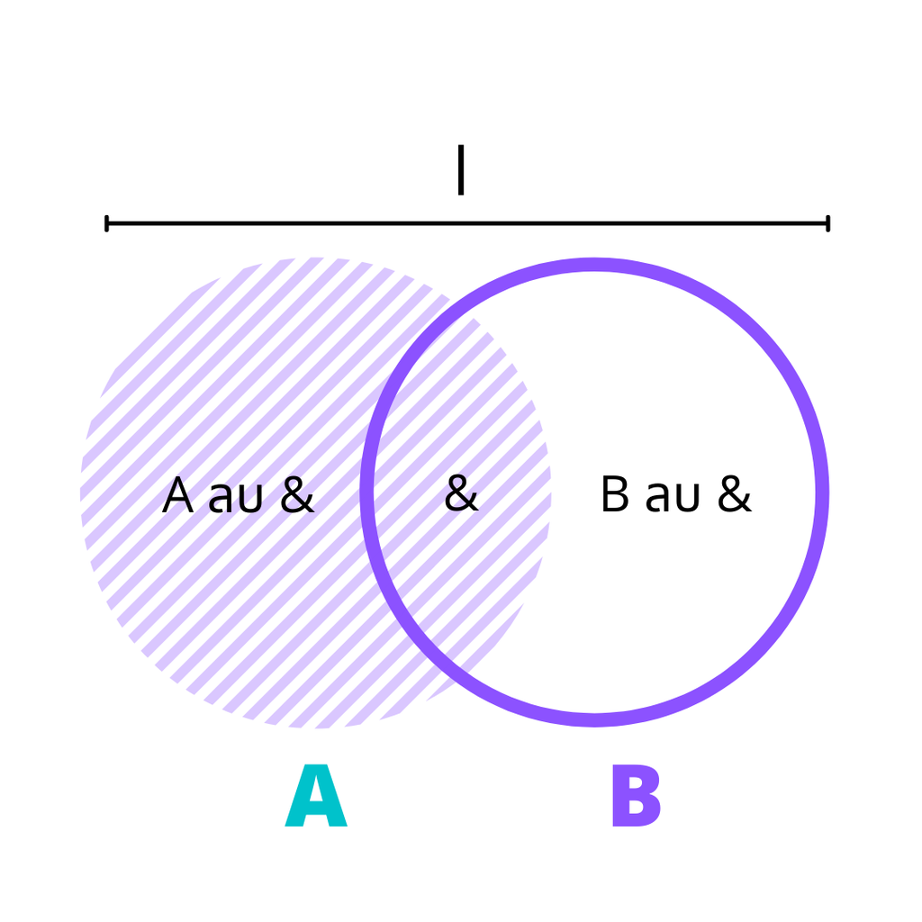

**สมมติ**ว่ามี data 2 ชุด เราต้องการเลือก ชุดข้อมูลบางชุดใน A และ ชุดข้อมูลบางชุดใน B ถ้าเราต้องการทั้งหมด เราจะใช้ **หรือ** สัญลักษณ์ `|` ในสมการ

แต่หากว่าเราต้องการ data ชุดข้อมูลบางชุดใน A แต่ชุดข้อมูลนี้ต้องปรากฎพร้อมกันใน B ด้วย เราจะใช้ **และ** สัญลักษณ์`&`ในสมการ

เช่น เราต้องการ country คือ Canada และ Thailand และทั้ง Canada และ Thailand จะต้องมีผู้ติดเชื้อเกิน 20 ราย

```r
Covid_th_can <- Data[Data$country == "Canada" | Data$country == "Thailand", ]
head(Covid_th_can)
```

```
##         date province country cases population
## 1 2020-01-22  Alberta  Canada     0    4413146
## 2 2020-01-23  Alberta  Canada     0    4413146
## 3 2020-01-24  Alberta  Canada     0    4413146
## 4 2020-01-25  Alberta  Canada     0    4413146
## 5 2020-01-26  Alberta  Canada     0    4413146
## 6 2020-01-27  Alberta  Canada     0    4413146
```

```r
Covid_th_can_20 <- Covid_th_can[Covid_th_can$cases >= 20, ]
head(Covid_th_can_20)
```

```
##          date province country cases population
## 57 2020-03-18  Alberta  Canada    23    4413146
## 58 2020-03-19  Alberta  Canada    22    4413146
## 59 2020-03-20  Alberta  Canada    27    4413146
## 60 2020-03-21  Alberta  Canada    49    4413146
## 61 2020-03-22  Alberta  Canada    64    4413146
## 62 2020-03-23  Alberta  Canada    42    4413146
```

Note : หากผู้ใช้ชำนาญแล้วแนะนำให้เขียนอยู่ในบรรทัดเดียวกันเลยค่า

ทั้งนี้ หากเราอยากนับจำนวนวันที่เคสติดเชื้อมากกว่า 20 รายใน `Canada` และ `Thailand` เราสามารถใช้คำสั่ง `table()` โดยระบุตัวแปรกลุ่มที่เราต้องการ

```r
table(Covid_th_can_20$country)
```

```
##
##   Canada Thailand
##     3856      602
```

และถ้าหากเราต้องการค่าเฉลี่ยเคสที่ติดโควิดใน `Canada` และ `Thailand` ในช่วงเวลาใน dataset เราสามารถหาได้โดยการใช้คำสั่งพื้นฐานของ R คือ `mean()`

```r
mean(Covid_th_can_20$cases)
```

```
## [1] 1095.29
```

```r
sd(Covid_th_can_20$cases)
```

```
## [1] 2591.22
```

```r
median(Covid_th_can_20$cases)
```

```
## [1] 250
```

```r
sqrt(mean(Covid_th_can_20$cases))
```

```
## [1] 33.09516
```

**ข้อควรระวัง**คือ การหาค่าเฉลี่ยดังกล่าวคือการหาค่าเฉลี่ยรวมของ `Canada` และ `Thailand` ค่า หากทบทวนการ subset ด้านบน เราสามารถแยก `data` ของ `Canada` และ `Thailand` ออกจากกันได้ และหาค่าเฉลี่ย แต่เดี๋ยวเราจะได้เริ่มใช้ `packages` ที่ให้ข้อมูลเชิงซับซ้อนได้มากขึ้นในบทต่อไป :)

`Happy Coding —-)`